# Red Wine Analysis

*by Praneetha Potiny*

This project discusses 12 attributes of red wine from a data set containing 1599 rows.

# Univariate Plots Section

```
##        X          fixed.acidity   volatile.acidity  citric.acid
##  Min.   :   1.0   Min.   : 4.60   Min.   :0.1200   Min.   :0.000
##  1st Qu.: 400.5   1st Qu.: 7.10   1st Qu.:0.3900   1st Qu.:0.090
##  Median : 800.0   Median : 7.90   Median :0.5200   Median :0.260
##  Mean   : 800.0   Mean   : 8.32   Mean   :0.5278   Mean   :0.271
##  3rd Qu.:1199.5   3rd Qu.: 9.20   3rd Qu.:0.6400   3rd Qu.:0.420
##  Max.   :1599.0   Max.   :15.90   Max.   :1.5800   Max.   :1.000
##  residual.sugar     chlorides       free.sulfur.dioxide
##  Min.   : 0.900   Min.   :0.01200   Min.   : 1.00
##  1st Qu.: 1.900   1st Qu.:0.07000   1st Qu.: 7.00
##  Median : 2.200   Median :0.07900   Median :14.00
##  Mean   : 2.539   Mean   :0.08747   Mean   :15.87
##  3rd Qu.: 2.600   3rd Qu.:0.09000   3rd Qu.:21.00
##  Max.   :15.500   Max.   :0.61100   Max.   :72.00
##  total.sulfur.dioxide    density             pH          sulphates
##  Min.   :  6.00       Min.   :0.9901   Min.   :2.740   Min.   :0.3300
##  1st Qu.: 22.00       1st Qu.:0.9956   1st Qu.:3.210   1st Qu.:0.5500
##  Median : 38.00       Median :0.9968   Median :3.310   Median :0.6200
##  Mean   : 46.47       Mean   :0.9967   Mean   :3.311   Mean   :0.6581
##  3rd Qu.: 62.00       3rd Qu.:0.9978   3rd Qu.:3.400   3rd Qu.:0.7300
##  Max.   :289.00       Max.   :1.0037   Max.   :4.010   Max.   :2.0000
##     alcohol         quality
##  Min.   : 8.40   Min.   :3.000
##  1st Qu.: 9.50   1st Qu.:5.000
##  Median :10.20   Median :6.000
##  Mean   :10.42   Mean   :5.636
##  3rd Qu.:11.10   3rd Qu.:6.000
##  Max.   :14.90   Max.   :8.000
```

```
## 'data.frame':    1599 obs. of  13 variables:
##  $ X                   : int  1 2 3 4 5 6 7 8 9 10 ...
##  $ fixed.acidity       : num  7.4 7.8 7.8 11.2 7.4 7.4 7.9 7.3 7.8 7.5 ...
##  $ volatile.acidity    : num  0.7 0.88 0.76 0.28 0.7 0.66 0.6 0.65 0.58 0.5 ...
##  $ citric.acid         : num  0 0 0.04 0.56 0 0 0.06 0 0.02 0.36 ...
##  $ residual.sugar      : num  1.9 2.6 2.3 1.9 1.9 1.8 1.6 1.2 2 6.1 ...
##  $ chlorides           : num  0.076 0.098 0.092 0.075 0.076 0.075 0.069 0.065 0.073 0.071 ...
##  $ free.sulfur.dioxide : num  11 25 15 17 11 13 15 15 9 17 ...
##  $ total.sulfur.dioxide: num  34 67 54 60 34 40 59 21 18 102 ...
##  $ density             : num  0.998 0.997 0.997 0.998 0.998 ...
##  $ pH                  : num  3.51 3.2 3.26 3.16 3.51 3.51 3.3 3.39 3.36 3.35 ...
##  $ sulphates           : num  0.56 0.68 0.65 0.58 0.56 0.56 0.46 0.47 0.57 0.8 ...
##  $ alcohol             : num  9.4 9.8 9.8 9.8 9.4 9.4 9.4 10 9.5 10.5 ...
##  $ quality             : int  5 5 5 6 5 5 5 7 7 5 ...
```

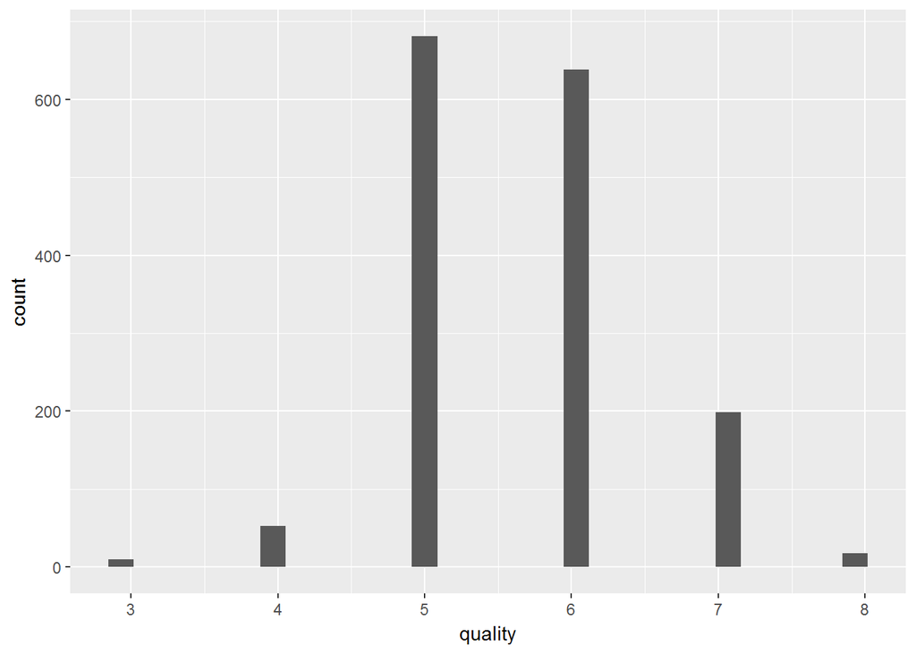

Most of the wines have a quality of 5 or 6. Since, I’m going to be measuring quality as a categorical variable, I converted it into a factor.

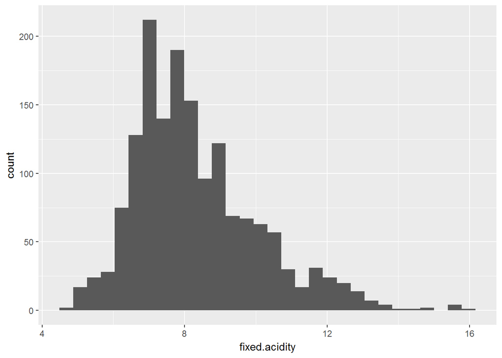

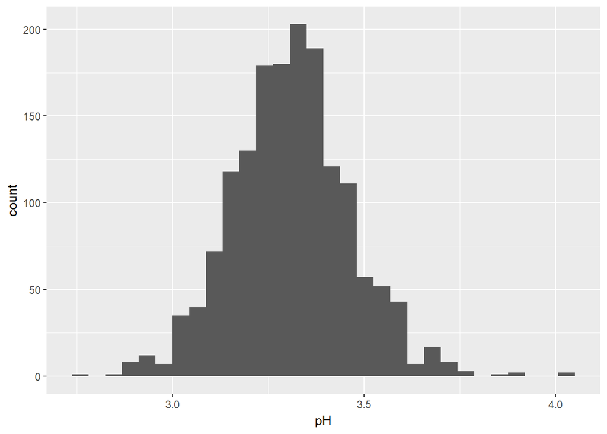

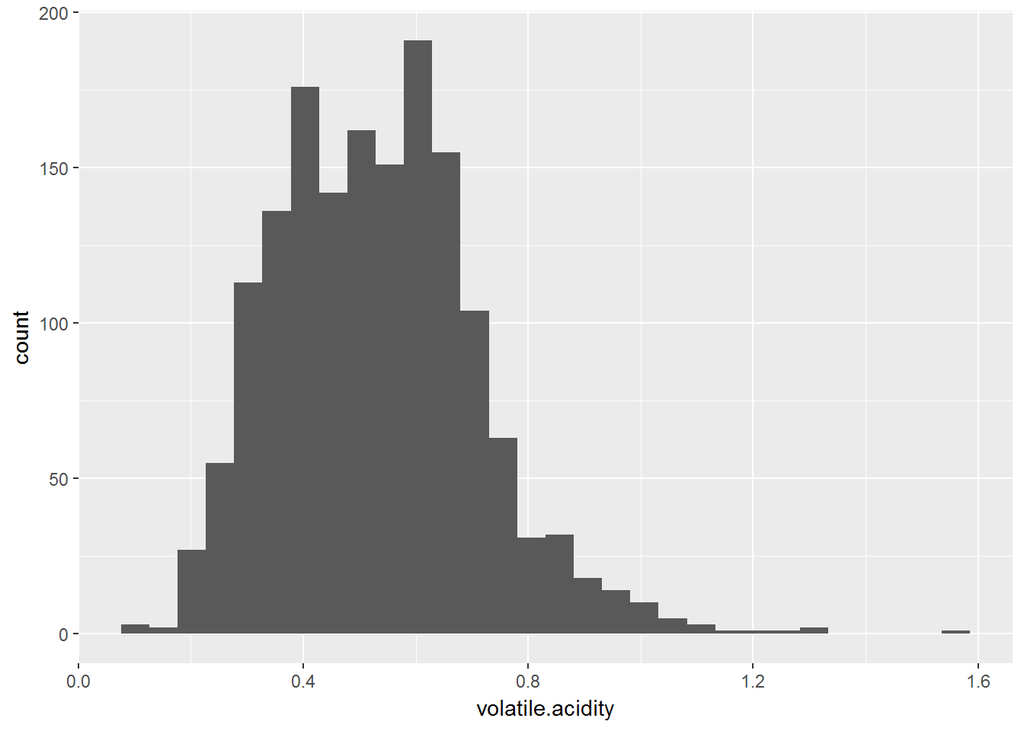

After doing research, I learned that high amounts of volatile acidity can lead to spoilage. This leads me to believe that the data-point near 1.6 should have a lower quality.

```
##        X        fixed.acidity volatile.acidity  citric.acid residual.sugar
##  Min.   :1300   Min.   :7.6   Min.   :1.58     Min.   :0    Min.   :2.1
##  1st Qu.:1300   1st Qu.:7.6   1st Qu.:1.58     1st Qu.:0    1st Qu.:2.1
##  Median :1300   Median :7.6   Median :1.58     Median :0    Median :2.1
##  Mean   :1300   Mean   :7.6   Mean   :1.58     Mean   :0    Mean   :2.1
##  3rd Qu.:1300   3rd Qu.:7.6   3rd Qu.:1.58     3rd Qu.:0    3rd Qu.:2.1
##  Max.   :1300   Max.   :7.6   Max.   :1.58     Max.   :0    Max.   :2.1
##    chlorides     free.sulfur.dioxide total.sulfur.dioxide    density
##  Min.   :0.137   Min.   :5           Min.   :9            Min.   :0.9948
##  1st Qu.:0.137   1st Qu.:5           1st Qu.:9            1st Qu.:0.9948
##  Median :0.137   Median :5           Median :9            Median :0.9948
##  Mean   :0.137   Mean   :5           Mean   :9            Mean   :0.9948
##  3rd Qu.:0.137   3rd Qu.:5           3rd Qu.:9            3rd Qu.:0.9948
##  Max.   :0.137   Max.   :5           Max.   :9            Max.   :0.9948
##        pH        sulphates      alcohol     quality
##  Min.   :3.5   Min.   :0.4   Min.   :10.9   3:1
##  1st Qu.:3.5   1st Qu.:0.4   1st Qu.:10.9   4:0
##  Median :3.5   Median :0.4   Median :10.9   5:0
##  Mean   :3.5   Mean   :0.4   Mean   :10.9   6:0
##  3rd Qu.:3.5   3rd Qu.:0.4   3rd Qu.:10.9   7:0
##  Max.   :3.5   Max.   :0.4   Max.   :10.9   8:0
```

As expected, the quality is 3, the lowest in the data-set.

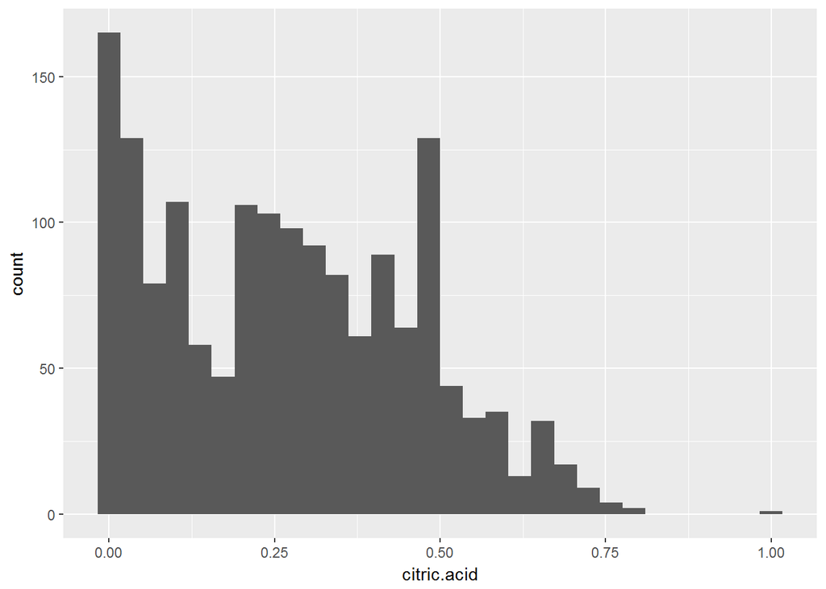

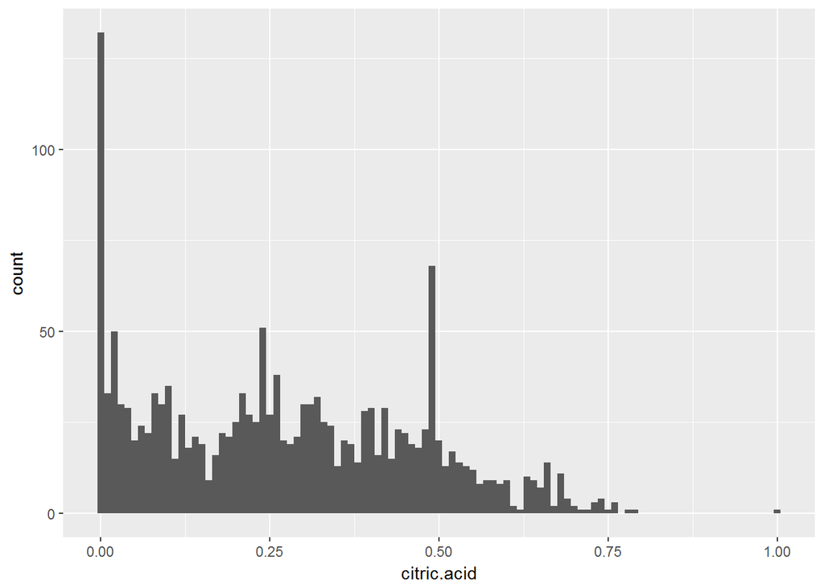

After changing the binwidth, it’s easier to see that most of the wines contain citric acid at proportions of 0, 0.25, and 0.5. There are a few at the 1.00 mark, that seem strange.

I’m going to take a look at those specific wines:

```
##        X       fixed.acidity volatile.acidity  citric.acid residual.sugar
##  Min.   :152   Min.   :9.2   Min.   :0.52     Min.   :1    Min.   :3.4
##  1st Qu.:152   1st Qu.:9.2   1st Qu.:0.52     1st Qu.:1    1st Qu.:3.4
##  Median :152   Median :9.2   Median :0.52     Median :1    Median :3.4
##  Mean   :152   Mean   :9.2   Mean   :0.52     Mean   :1    Mean   :3.4
##  3rd Qu.:152   3rd Qu.:9.2   3rd Qu.:0.52     3rd Qu.:1    3rd Qu.:3.4
##  Max.   :152   Max.   :9.2   Max.   :0.52     Max.   :1    Max.   :3.4
##    chlorides    free.sulfur.dioxide total.sulfur.dioxide    density
##  Min.   :0.61   Min.   :32          Min.   :69           Min.   :0.9996
##  1st Qu.:0.61   1st Qu.:32          1st Qu.:69           1st Qu.:0.9996
##  Median :0.61   Median :32          Median :69           Median :0.9996
##  Mean   :0.61   Mean   :32          Mean   :69           Mean   :0.9996
##  3rd Qu.:0.61   3rd Qu.:32          3rd Qu.:69           3rd Qu.:0.9996
##  Max.   :0.61   Max.   :32          Max.   :69           Max.   :0.9996
##        pH         sulphates    alcohol    quality
##  Min.   :2.74   Min.   :2   Min.   :9.4   3:0
##  1st Qu.:2.74   1st Qu.:2   1st Qu.:9.4   4:1
##  Median :2.74   Median :2   Median :9.4   5:0
##  Mean   :2.74   Mean   :2   Mean   :9.4   6:0
##  3rd Qu.:2.74   3rd Qu.:2   3rd Qu.:9.4   7:0
##  Max.   :2.74   Max.   :2   Max.   :9.4   8:0
```

There’s only one object, and there does not seem to be anything else strange with the numbers.

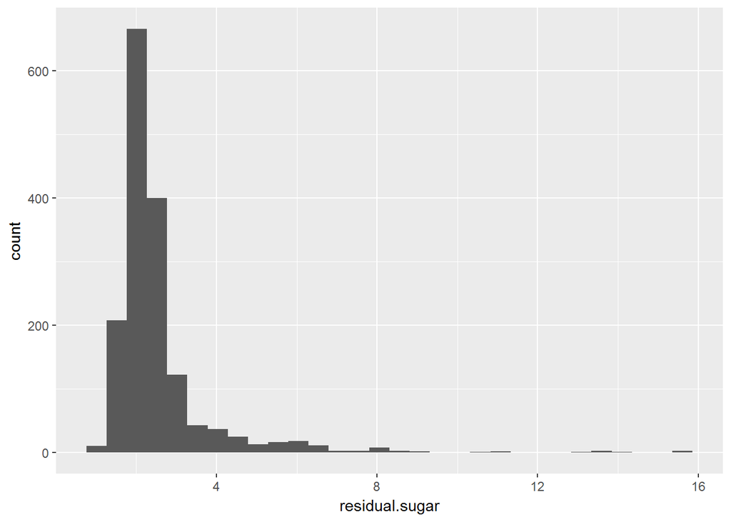

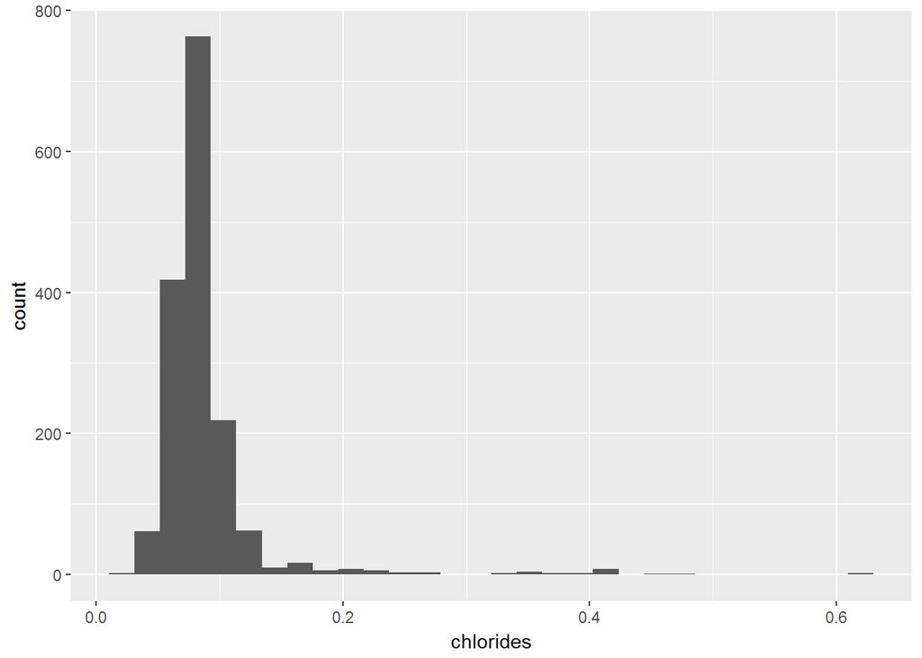

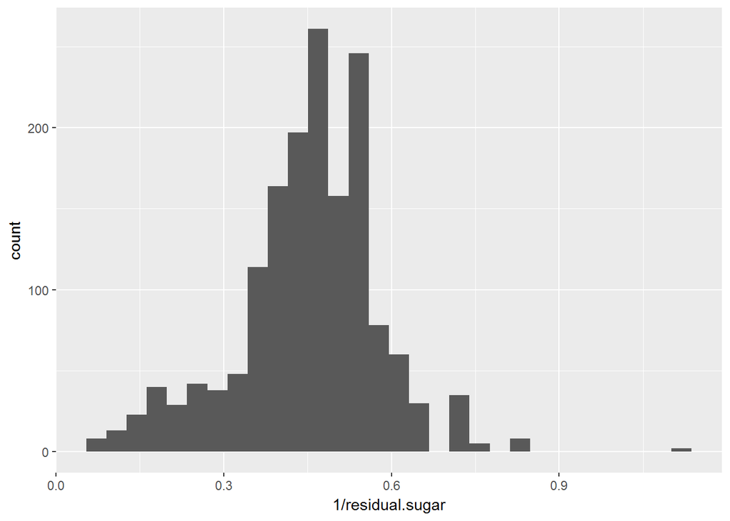

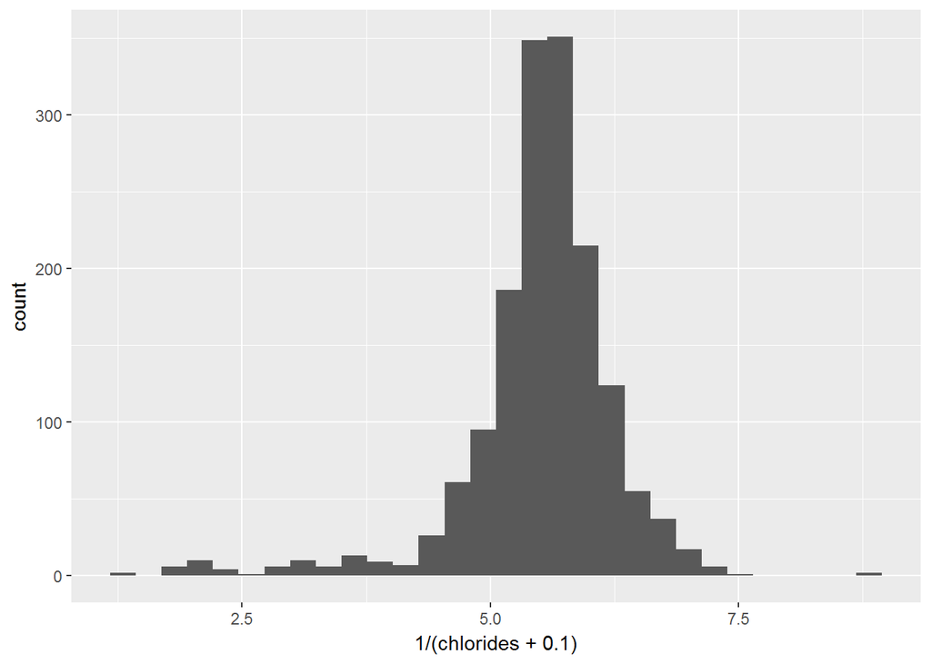

It looks like most of the residual sugar is between 1-3, and most of the chlorides are between 0.5-0.10. Since these two variables are highly skewed, I decided to take the inverse.

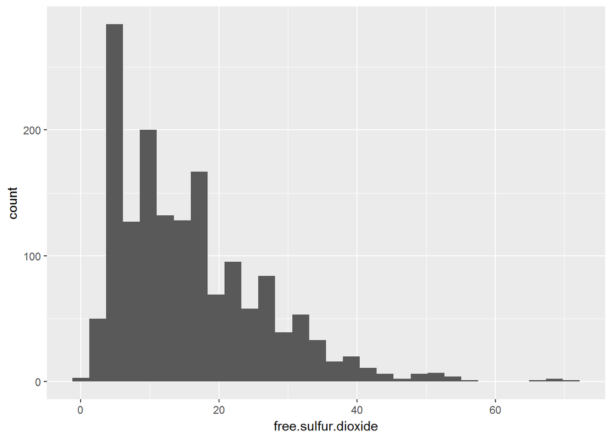

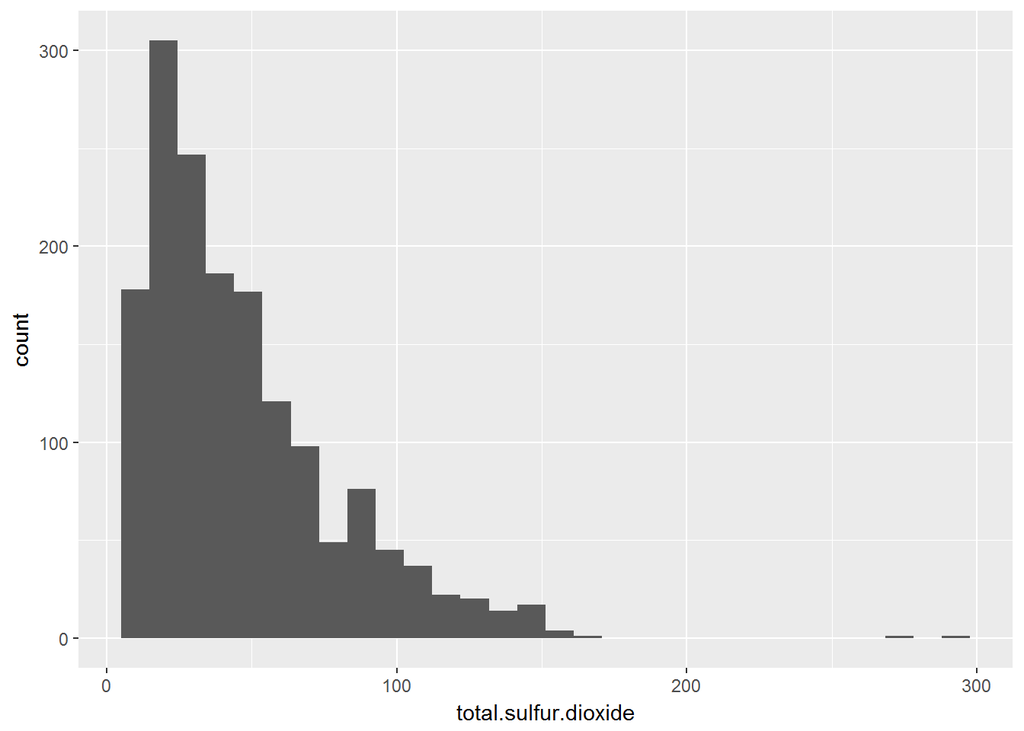

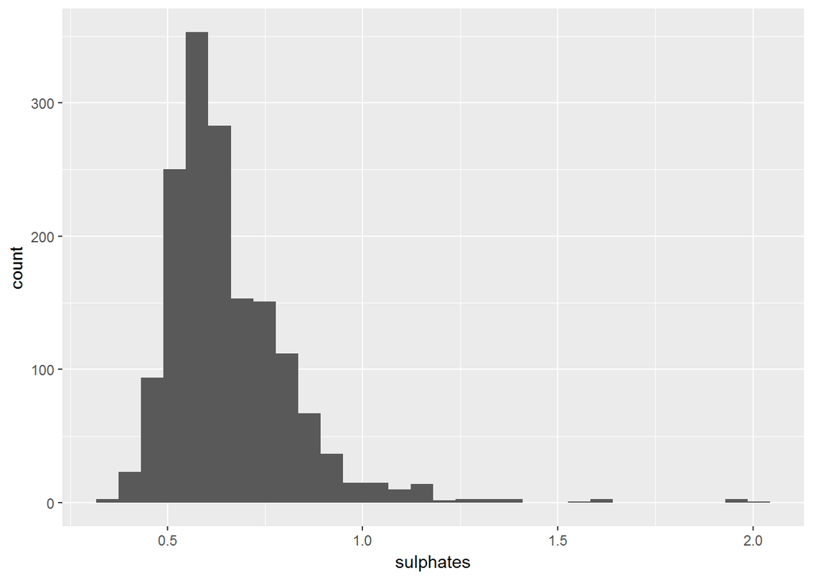

They all look skewed, so I’ll transform the data again.

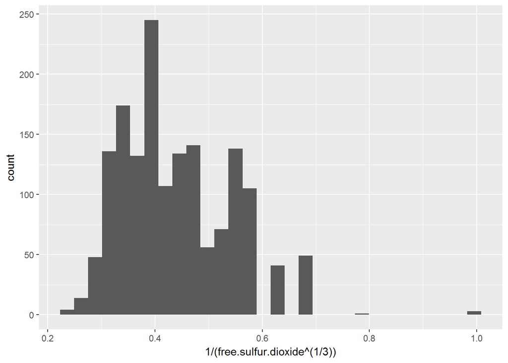

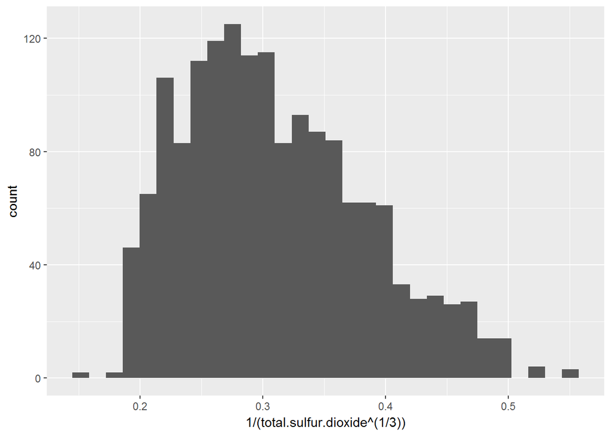

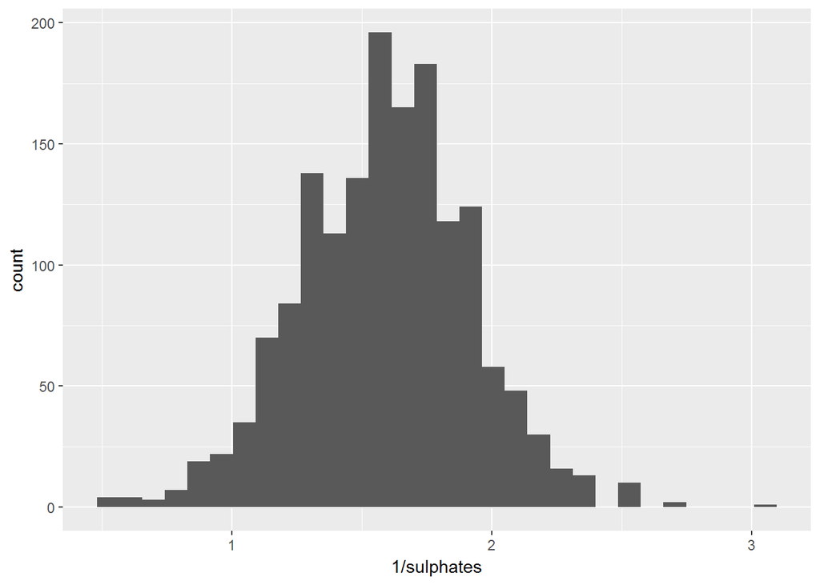

It seems like most of the data is highly skewed such that log transformations do not normalize the data. Taking the inverse for the sulfur dioxide amounts, skewed the data to the right, so I took the cube root before doing so.

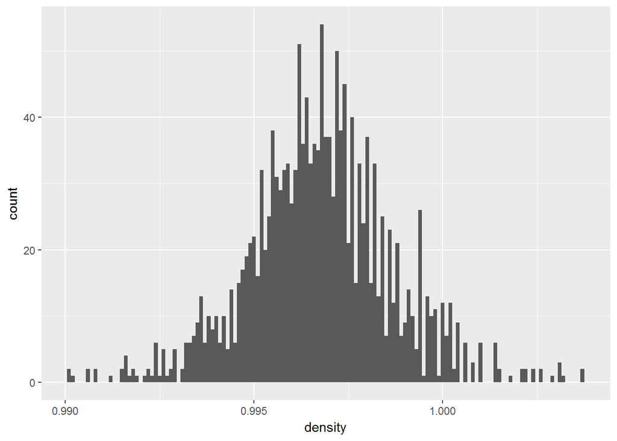

There is very little variability between the densities.

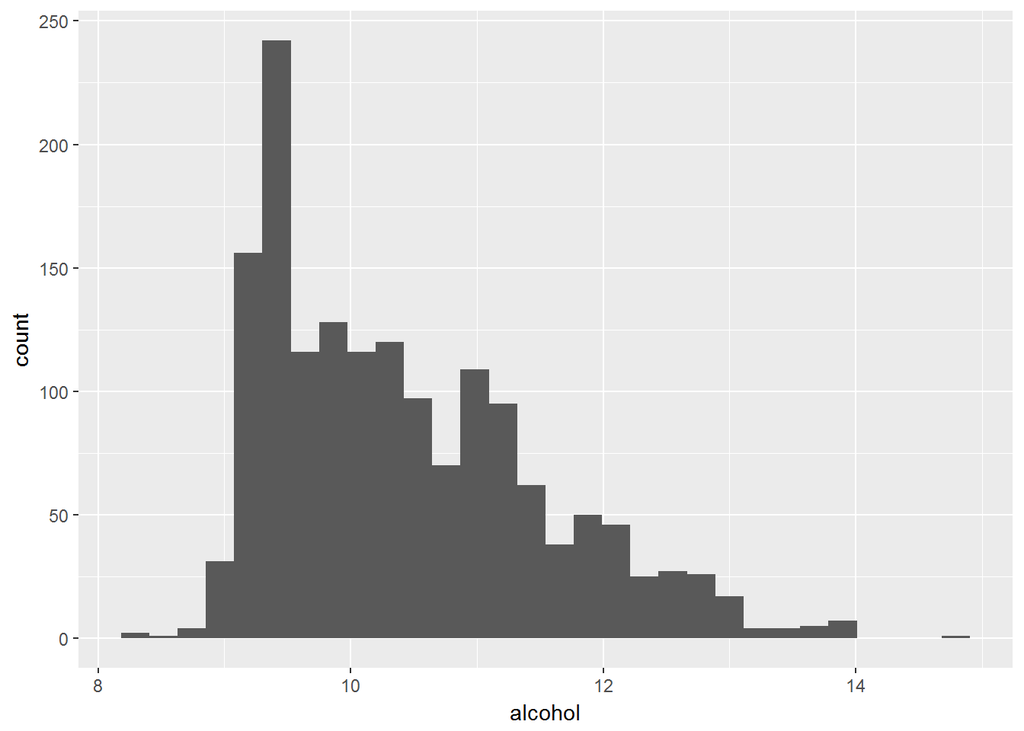

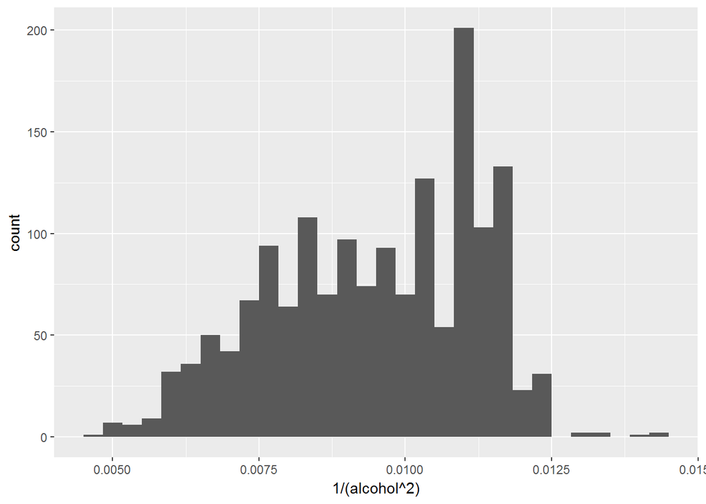

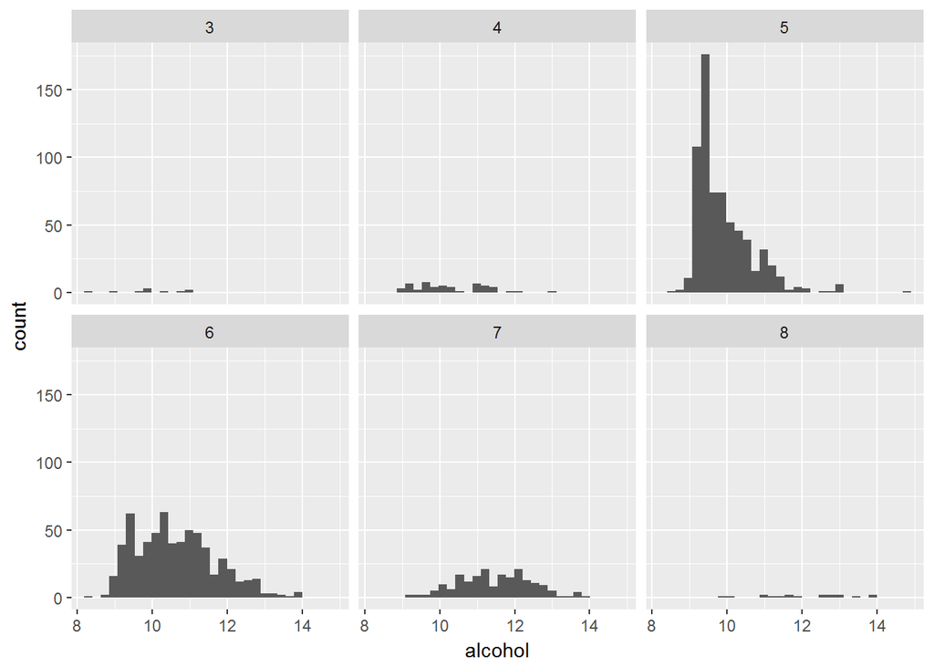

I took the inverse of alcohol because this variable was also skewed. Using the original variable, I can see that the distribution seems to shift to the right as quality increases.

# Univariate Analysis

### What is the structure of your dataset?

- 1599 objects
- 12 features (not including ‘x’ which is the ID).
- All features are numeric except for ‘quality’ with a range [3, 8]

##### Key Notes

- A data-point with high volatile acidity had a quality of 3
- There are multiple wines in the dataset with the same contents (feature-wise in this data-set)
- Citric acid peaks at 0, 0.25, and 0.5
- Sulfur dioxide seems to have two peaks
- Alcohol content seems to shift to the right as quality increases

### What is/are the main feature(s) of interest in your dataset?

The main feature of interest in this dataset is quality.

### What other features in the dataset do you think will help support your investigation into your feature(s) of interest?

For now, I think alcohol content and volatile acidity will strongly help with investigating the quality of wine. Citric acid and free sulfur dioxide might also help with investigation.

### Did you create any new variables from existing variables in the dataset?

I did not create any new variables.

### Of the features you investigated, were there any unusual distributions? Did you perform any operations on the data to tidy, adjust, or change the form of the data? If so, why did you do this?

I also created two subsets called volatile_high and citric_1. For citric_1, I took a subset of data-points that were 100% citric acid. However, I saw that their other features were not as extreme, so I ignored it. For volatile high, I also wanted to check data-points with a high amount of volatile acidity. After researching, I discovered that these high amounts can be bad for wine. As suspected, the quality was a 3, which is the lowest possible in this data-set.

# Bivariate Plots Section

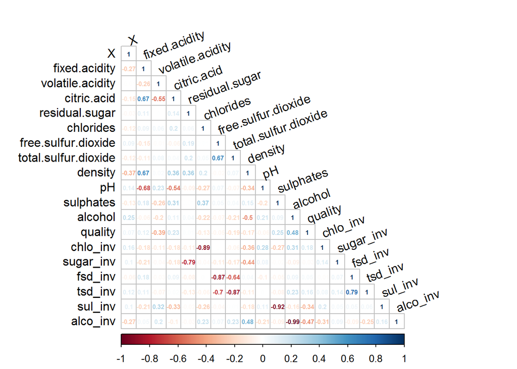

Alcohol and volatile.acidity have moderate correlations with quality. Citric.acid has somewhat of a correlation with quality but free.sulfur.dioxide does not. There also seems to be a moderate correlation between sul_inv and quality. One thing I noticed from the plot is that density is moderately correlated with many variables on this list.

Most of the inverse variables seem to have an improved correlation besides alco_inv (alcohol). The variable with the most diverse improvement in correlation was chlo_inv (chlorides). The variable that improved its correlation with quality was sul_inv (sulphates).

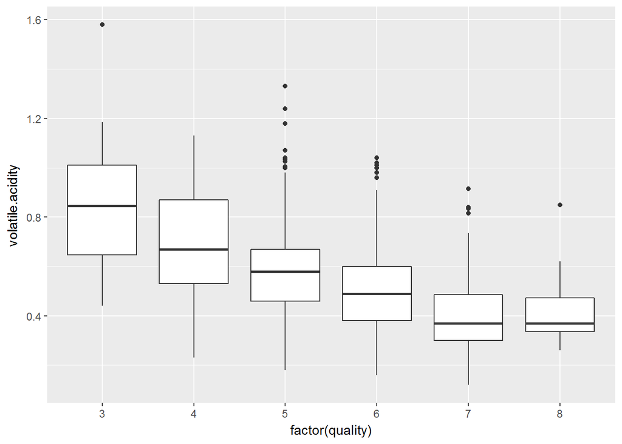

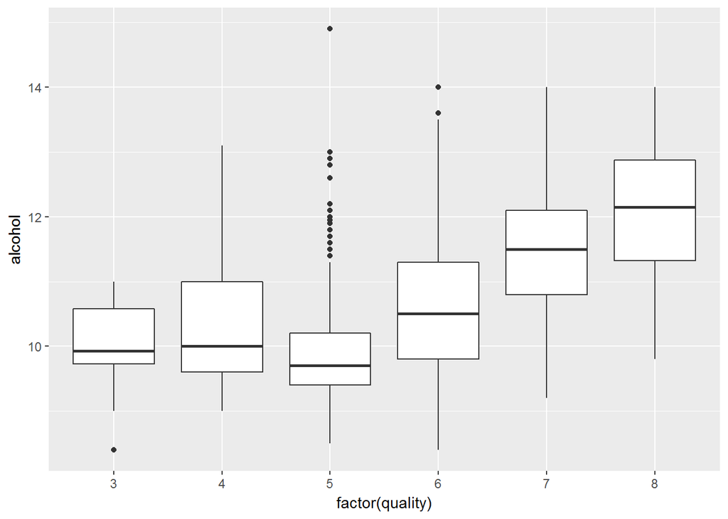

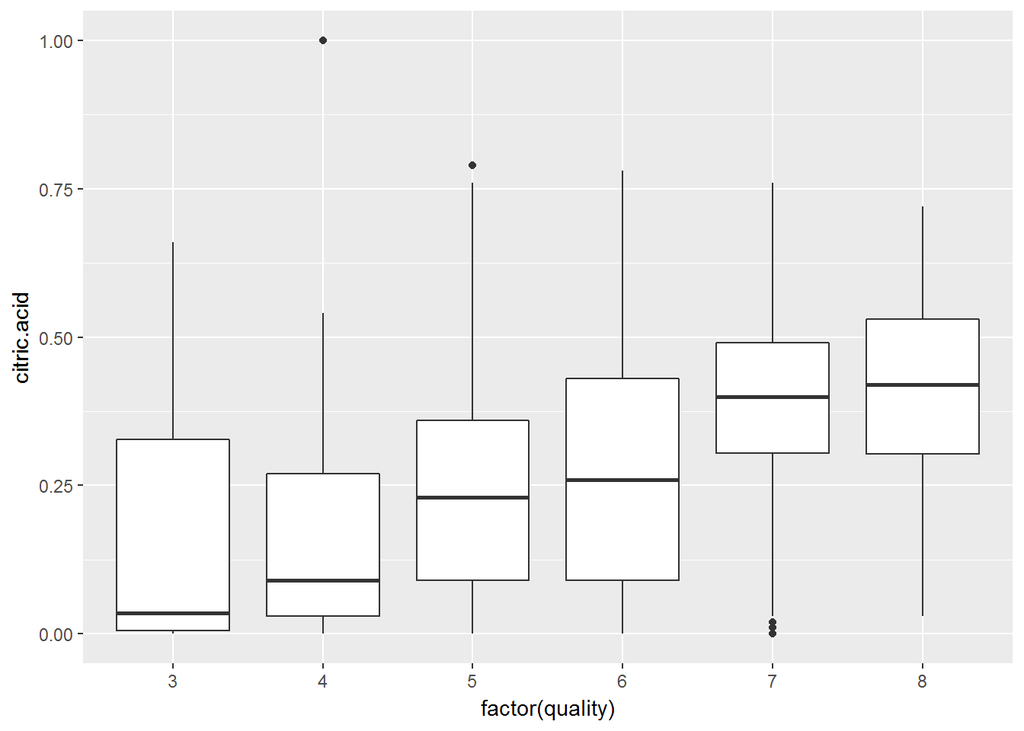

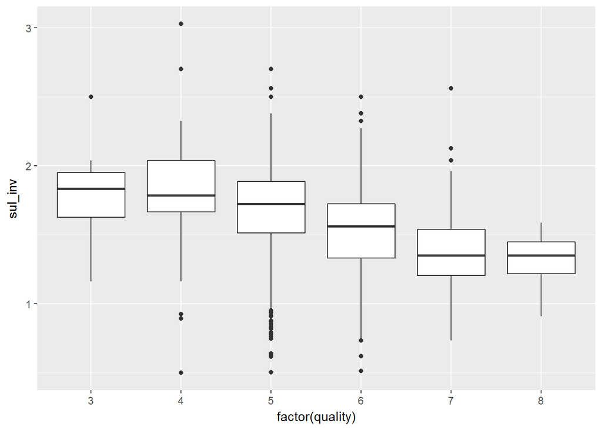

It seems like quality is positively correlated with alcohol content and citric acid, but negatively correlated with volatile acidity and sul_inv.

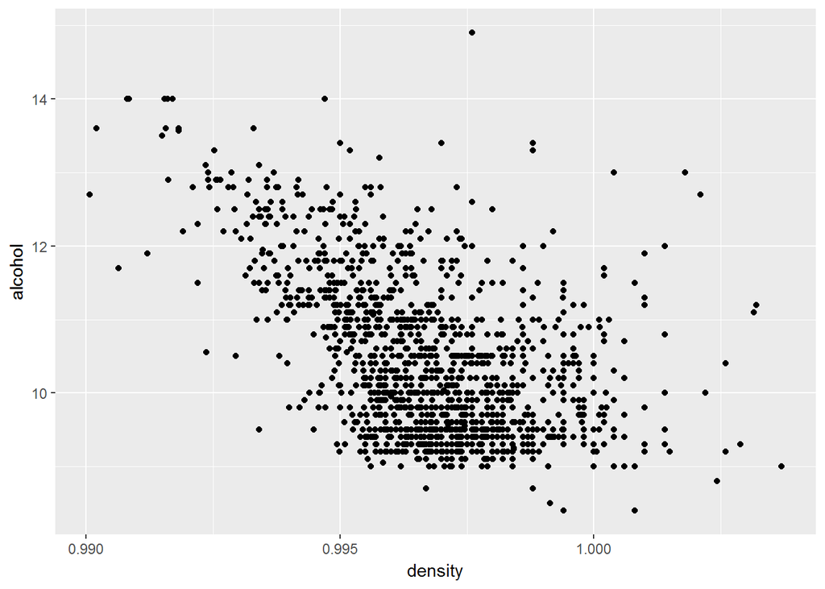

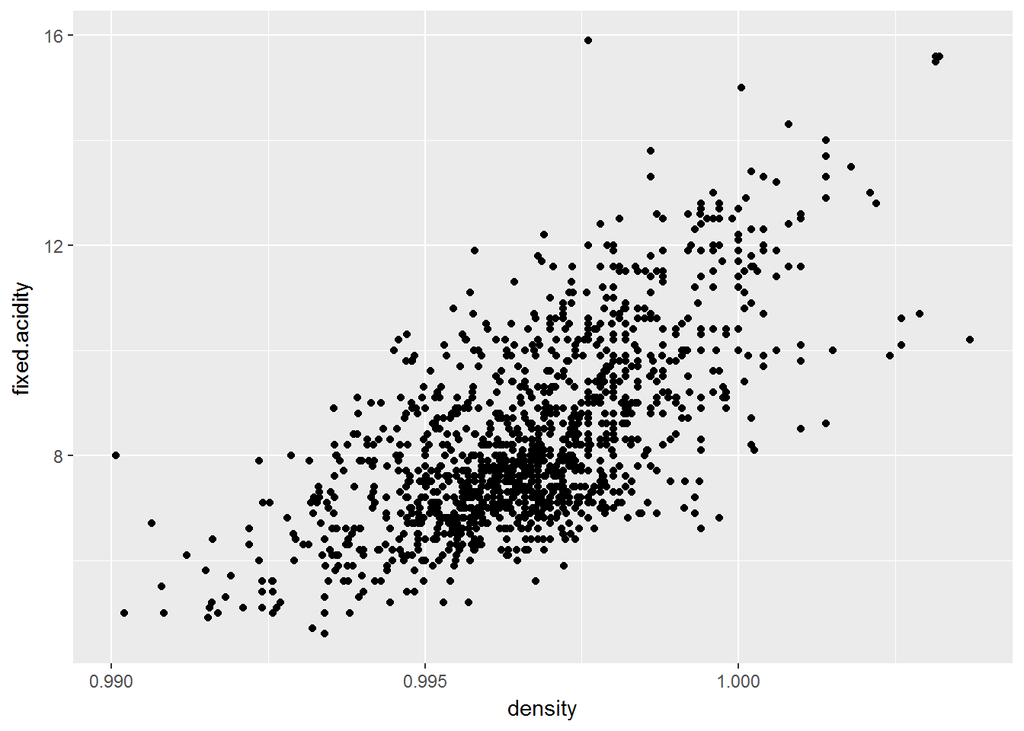

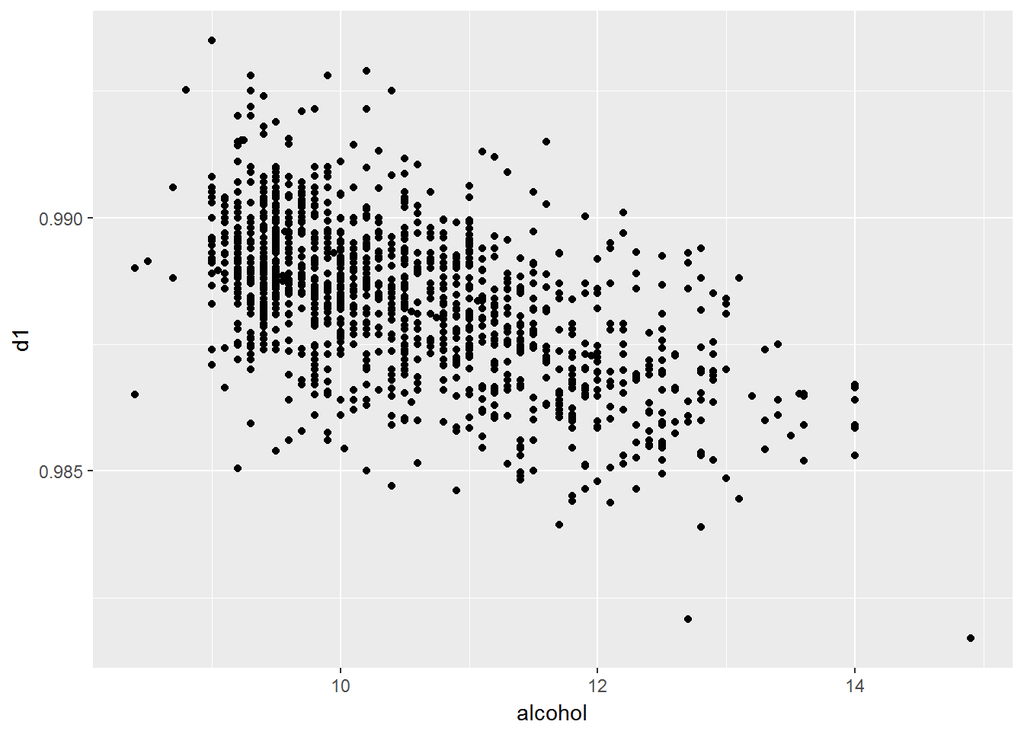

##### Correlation with Alcohol (Density, Modified Density)

```
## [1] -0.4961798
```

```
## [1] -0.5585895
```

##### Correlation with Quality (Density, Modified Density)

```
## [1] -0.1749192
```

```
## [1] -0.3679412
```

After converting fixed acidity from g/L to g/mL, I subtracted it from density. This seems to improve density’s correlation with alcohol and quality.

# Bivariate Analysis

### Did you observe any interesting relationships between the other features (not the main feature(s) of interest)?

Density had a moderate correlation with many features in this data-set, which were citric acid, residual sugar, fixed acidity and pH. Taking the inverse of chlorides, seems to have increased the correlation between it and alcohol. After creating the new variable (density - fixed.acidity), I observed correlations of at least 0.15 with every variable in the data-set except sulphates. I was curious about the correlation of -0.55 between volatile acidity and citric acid. From my research, I learned that citric acid was a part of the fixed acidity. However, there is only a small correlation between fixed acidity and volatile acidity. I was also curious about the lack of correlation between sulphates and the sulfur dioxide levels.

### What was the strongest relationship you found?

The strongest correlation I found in this data-set was about 0.79 between the inverse-transformed variables free.sulfur.dioxide and total.sulfur.dioxide.